# MA8701 Advanced methods in statistical inference and learning

Example Data Analysis Report Project 1

Mette Langaas IMF/NTNU

07 February, 2021

# Preface

These are my suggestions for what the Data Analysis Project 1 report could look like. I am worried that you spend too much work on the report. The main aim is to get hands on experience with the topics of Part 1. I would not expect that you spend many days of working on the report.

If a group hands in a report which get a fail grade, they will get feedback and will be able to resubmit the report.

# Introduction

*Here you describe what is the aim of the analysis.*

The aim of the analysis is to find an interpretable model for estimating the level of prostate antigen PSA from 8 clinical measurements. Data are available from 97 males who were about to receive ratical prostatectomy.

I will use the standard data set on prostate cancer used in the ELS book - to show what a minimal solution could be.

## Data

_Write

- a few words on the data set to be used and on
- preprocessing of the data. Hopefully that is not very much, mainly maybe centering of reponse (if regression) and standardize the covariates._

The data is presented in ELS page Example 2, pages 3-4, and downloaded from http://statweb.stanford.edu/~tibs/ElemStatLearn.1stEd/ with information in the file `prostate.info` and data in `prostate.data`.

Response:

- the log of PSA (lpsa)

# Plan for statistical analyses

*Write down what your plan is.*

The data contains a column with information for use as traning and test data, with 67 observations for training and 30 for testing. The test data will be set aside for evaluation?

For model selection cross-validation will be used. Since interpretation is the prime interest and the data set is very small, we will not set aside a test set, and will therefore not have focus on comparing goodness of fit across different models.

This is a regression problem.

The boostrapping will be performed with a loop jointly across all three analyses, after each of the analyses are presented.

# Statistical analyses

## Reading data

```
## [1] 97 11
```

```
##  [1] "X"       "lcavol"  "lweight" "age"     "lbph"    "svi"     "lcp"
##  [8] "gleason" "pgg45"   "lpsa"    "train"
```

```
##   X     lcavol  lweight age      lbph svi       lcp gleason pgg45       lpsa
## 1 1 -0.5798185 2.769459  50 -1.386294   0 -1.386294       6     0 -0.4307829
## 2 2 -0.9942523 3.319626  58 -1.386294   0 -1.386294       6     0 -0.1625189
## 3 3 -0.5108256 2.691243  74 -1.386294   0 -1.386294       7    20 -0.1625189
## 4 4 -1.2039728 3.282789  58 -1.386294   0 -1.386294       6     0 -0.1625189
## 5 5  0.7514161 3.432373  62 -1.386294   0 -1.386294       6     0  0.3715636
## 6 6 -1.0498221 3.228826  50 -1.386294   0 -1.386294       6     0  0.7654678
##   train
## 1  TRUE
## 2  TRUE
## 3  TRUE
## 4  TRUE
## 5  TRUE
## 6  TRUE
```

## Decriptive statistics

Traning data, sample size 67

|  | lcavol | lweight | age | lbph | svi | lcp | gleason | pgg45 | lpsa |
| --- | --- | --- | --- | --- | --- | --- | --- | --- | --- |
| min | -1.35 | 2.37 | 41.00 | -1.39 | 0.00 | -1.39 | 6.00 | 0.00 | -0.43 |
| median | 1.47 | 3.60 | 65.00 | -0.05 | 0.00 | -0.80 | 7.00 | 15.00 | 2.57 |
| mean | 1.31 | 3.63 | 64.75 | 0.07 | 0.22 | -0.21 | 6.73 | 26.27 | 2.45 |
| max | 3.82 | 4.78 | 79.00 | 2.33 | 1.00 | 2.66 | 9.00 | 100.00 | 5.48 |
| sd | 1.24 | 0.48 | 7.50 | 1.46 | 0.42 | 1.40 | 0.71 | 29.30 | 1.21 |

Test data, sample size 30

|  | lcavol | lweight | age | lbph | svi | lcp | gleason | pgg45 | lpsa |
| --- | --- | --- | --- | --- | --- | --- | --- | --- | --- |
| min | -0.78 | 2.87 | 43.00 | -1.39 | 0.00 | -1.39 | 6.00 | 0.00 | 0.77 |
| median | 1.44 | 3.65 | 64.00 | 0.44 | 0.00 | -0.43 | 7.00 | 8.00 | 2.59 |
| mean | 1.43 | 3.71 | 61.90 | 0.16 | 0.20 | -0.10 | 6.80 | 20.17 | 2.54 |
| max | 3.47 | 6.11 | 70.00 | 2.17 | 1.00 | 2.90 | 9.00 | 90.00 | 5.58 |
| sd | 1.04 | 0.54 | 7.04 | 1.44 | 0.41 | 1.41 | 0.76 | 25.55 | 1.04 |

Center reponses and standardize all covariates - will not use as factors but numeric for the two ordinal and binary covariates.

## Least squares model fit

*Add comments to what you do and what you find.*

```
##
## Call:
## lm(formula = lpsa ~ lcavol + lweight + age + lbph + svi + lcp +
##     gleason + pgg45, data = strain)
##
## Residuals:
##      Min       1Q   Median       3Q      Max
## -1.64870 -0.34147 -0.05424  0.44941  1.48675
##
## Coefficients:
##               Estimate Std. Error t value Pr(>|t|)
## (Intercept) -2.347e-16  8.702e-02   0.000  1.00000
## lcavol       7.164e-01  1.335e-01   5.366 1.47e-06 ***
## lweight      2.926e-01  1.064e-01   2.751  0.00792 **
## age         -1.425e-01  1.021e-01  -1.396  0.16806
## lbph         2.120e-01  1.031e-01   2.056  0.04431 *
## svi          3.096e-01  1.254e-01   2.469  0.01651 *
## lcp         -2.890e-01  1.548e-01  -1.867  0.06697 .
## gleason     -2.091e-02  1.426e-01  -0.147  0.88389
## pgg45        2.773e-01  1.596e-01   1.738  0.08755 .
## ---
## Signif. codes:  0 '***' 0.001 '**' 0.01 '*' 0.05 '.' 0.1 ' ' 1
##
## Residual standard error: 0.7123 on 58 degrees of freedom
## Multiple R-squared:  0.6944, Adjusted R-squared:  0.6522
## F-statistic: 16.47 on 8 and 58 DF,  p-value: 2.042e-12
```

```
##                    2.5 %     97.5 %
## (Intercept) -0.174188643 0.17418864
## lcavol       0.449175029 0.98363900
## lweight      0.079689925 0.50559488
## age         -0.346964156 0.06186490
## lbph         0.005581926 0.41843328
## svi          0.058624481 0.56061459
## lcp         -0.598879566 0.02086834
## gleason     -0.306314488 0.26448745
## pgg45       -0.042112877 0.59680478
```

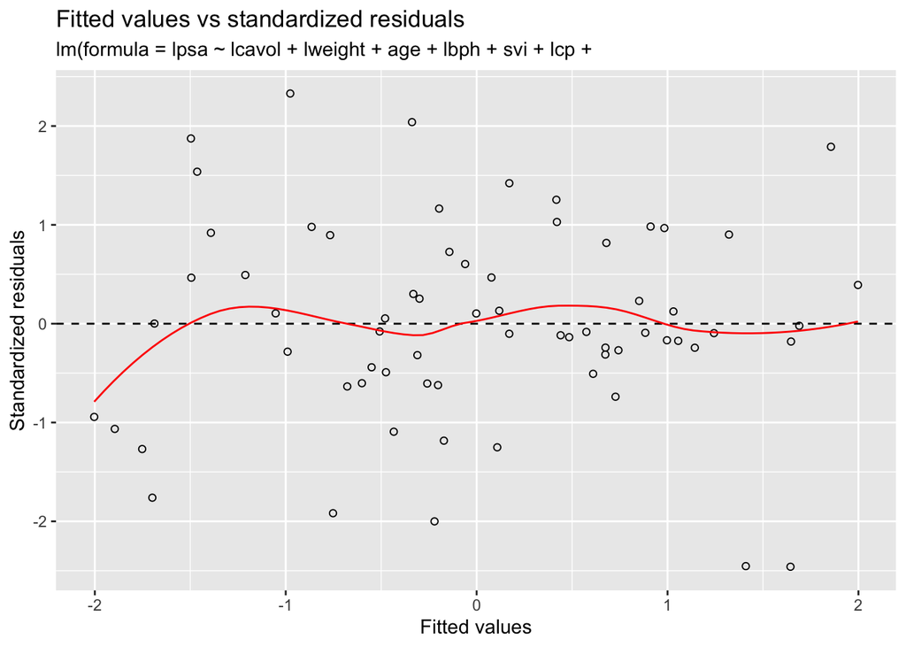

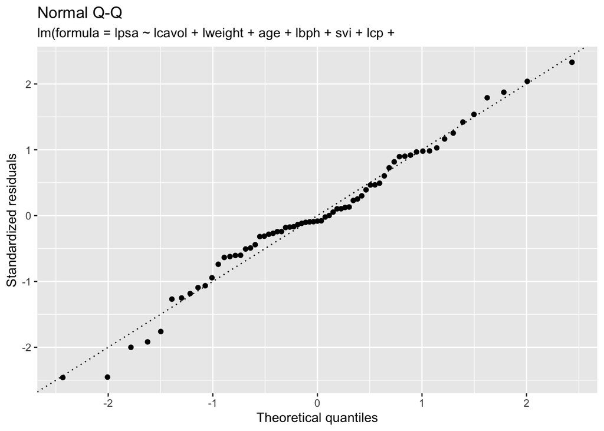

```
##
##  Anderson-Darling normality test
##
## data:  rstudent(full)
## A = 0.57619, p-value = 0.1293
```

## Ridge regression

*Add comments to what you do and what you find.*

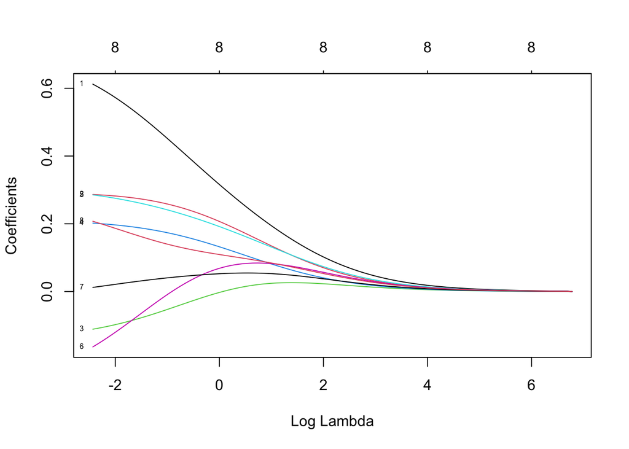

```r
ridgefit=glmnet(x=strainx,y=strainy,alpha=0)
plot(ridgefit,xvar="lambda",label=TRUE)
```

```r
cv.ridge=cv.glmnet(x=strainx,y=strainy,alpha=0)
print(paste("The lamda giving the smallest CV error",cv.ridge$lambda.min))
```

```
## [1] "The lamda giving the smallest CV error 0.08788804212004"
```

```r
print(paste("The 1sd err method lambda",cv.ridge$lambda.1se))
```

```
## [1] "The 1sd err method lambda 0.987267497024188"
```

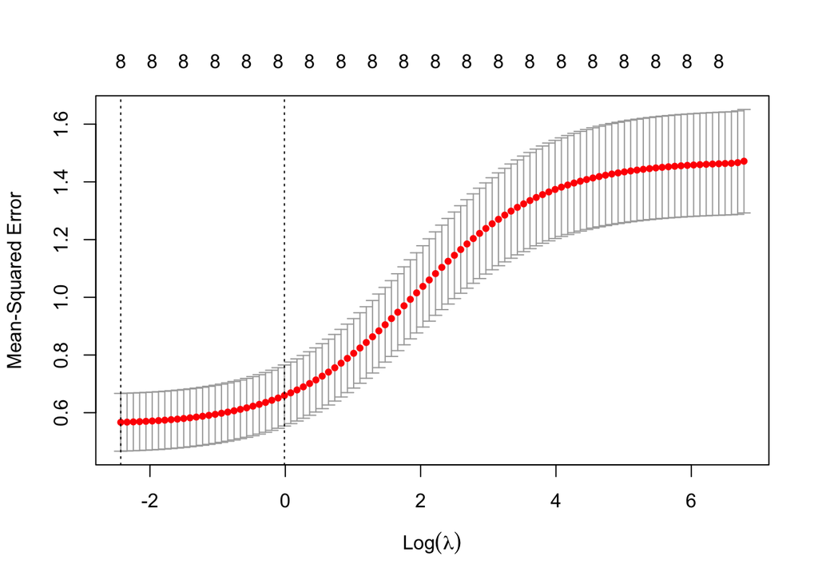

```r
plot(cv.ridge)
```

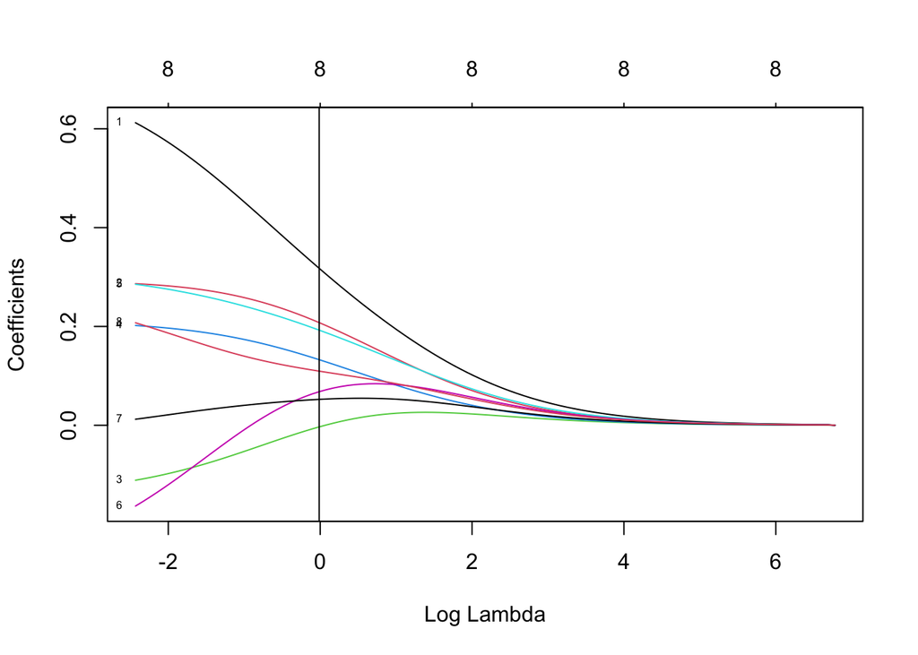

```r
# use 1sd error rule default
plot(ridgefit,xvar="lambda",label=TRUE);
abline(v=log(cv.ridge$lambda.1se));
```

## Lasso regression

*Add comments to what you do and what you find.*

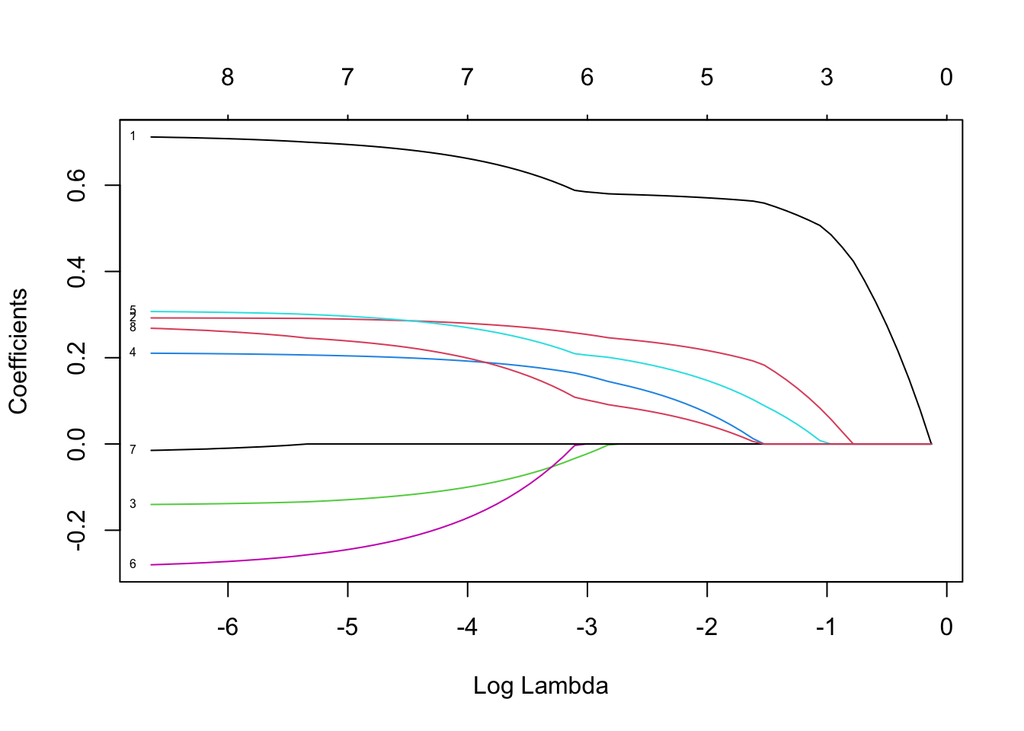

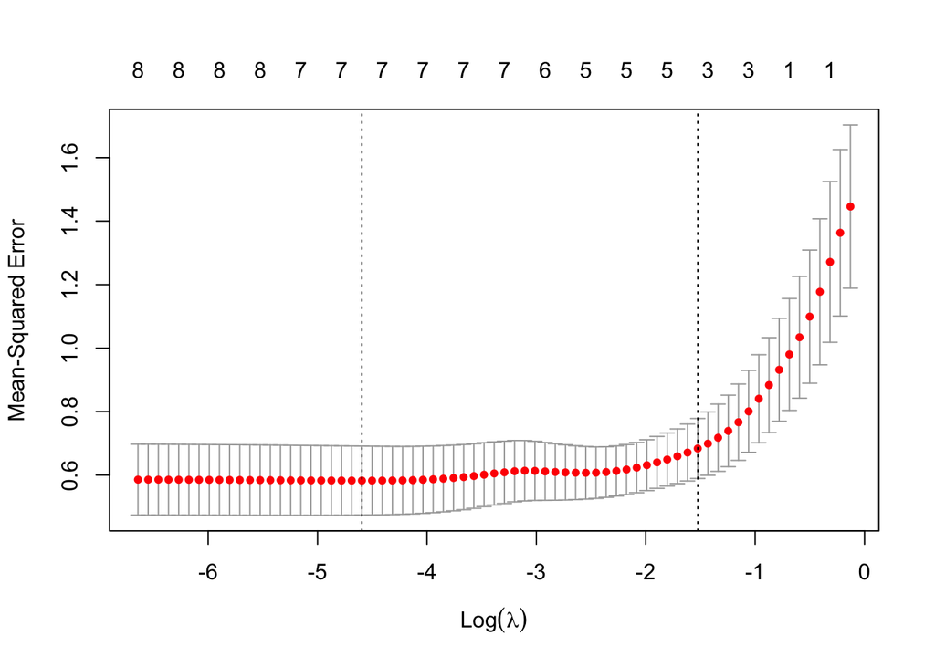

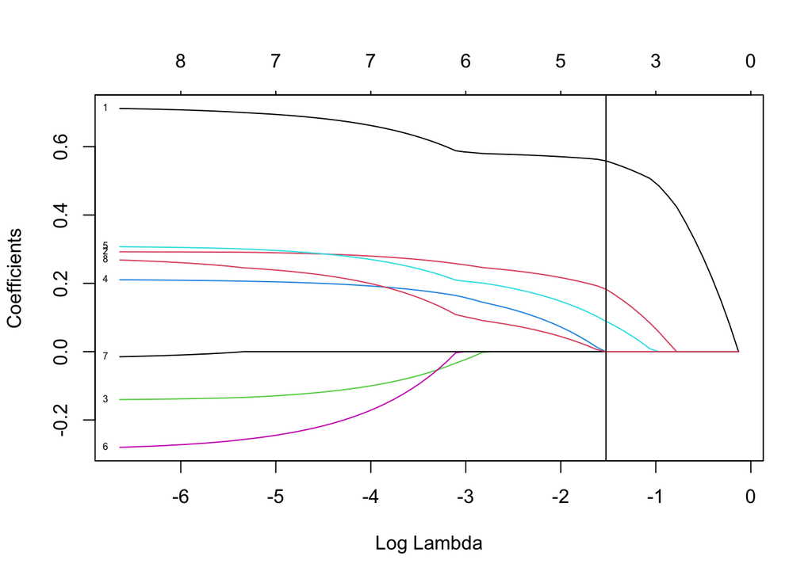

```
## 9 x 1 sparse Matrix of class "dgCMatrix"
##                         1
## (Intercept) -5.492944e-17
## lcavol       5.585015e-01
## lweight      1.829142e-01
## age          .
## lbph         .
## svi          8.898524e-02
## lcp          .
## gleason      .
## pgg45        .
```

# Inference for the model selection procedures

**under construction**

We now turn to bootstrapping for running an outer loop to get confidence intervals for regression parameters for the methods where model selection is used.

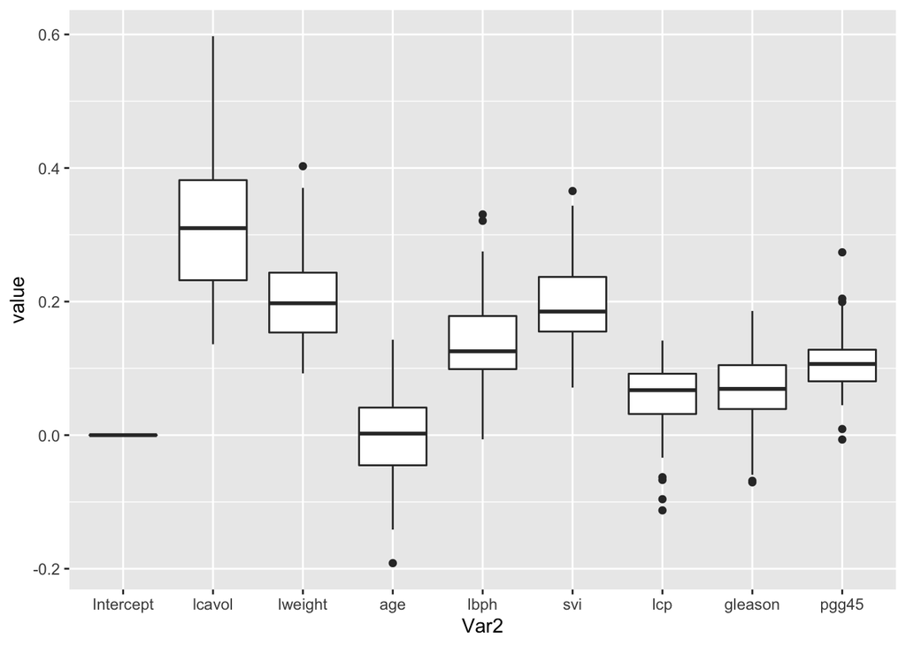

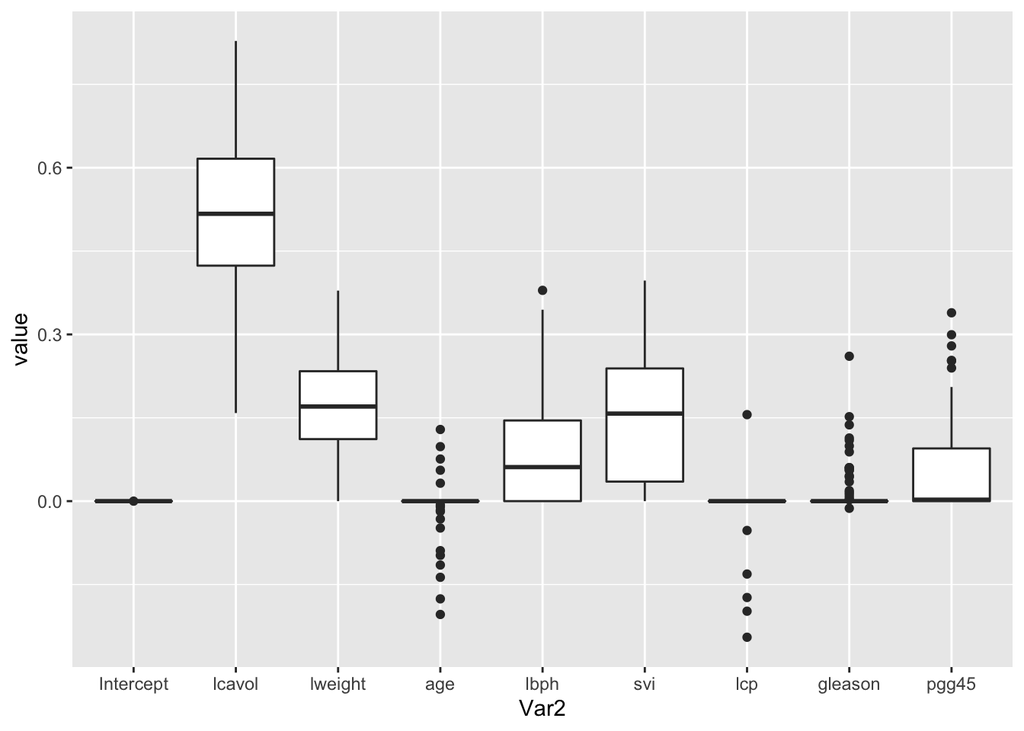

# Discussion

## Weaknesses

Try out gleason as factor? How about standardization of the factor?

# References

- R Core Team (2020). R: A language and environment for statistical computing. R Foundation for Statistical Computing, Vienna, Austria. https://www.R-project.org/.
- Jerome Friedman, Trevor Hastie, Robert Tibshirani (2010). Regularization Paths for Generalized Linear Models via Coordinate Descent. Journal of Statistical Software, 33(1), 1-22. URL http://www.jstatsoft.org/v33/i01/.